# rgumlib

2016-10-19

`rgumlib` is a set of R functions designed to perform uncertainty propagation according to the *GUM*[^1] and *GUM-Supp1*[^2] recommendations.

The package implements also various plotting functions, and tools for sensitivity analysis.

# 1 Other packages

`propagate`

# 2 Problem setup

## 2.1 Model definition

The model can be defined as an expression or a function. The difference is that analytic derivatives will be used for expressions, whereas functions require numerical derivatives. In all the examples we have been able to treat, this is not a choice criterion (no difference observed).

```r
# Expression analytique du modele
fExpr = expression( x1 + 2*x2 )
# or
fExpr = function(x1,x2) x1 + 2*x2
```

In practice, use of a function enables more complex models, for instance calls to external codes.

**Warning**: the only arguments of the function should be the uncertain variables and bear the same names as those used to define these variables (see below).

## 2.2 Input variables definition

### 2.2.1 GUM

To apply the combination of variances, one needs each variables to be characterized by its mean value and variance or standard uncertainty.

For an easier and more foolproof coding, we use the following convention:

- the mean value is stored in the variable, e.g. `x1`
- the standard uncertainty has the name of the variable extended by ‘.u’, e.g. `x1.u`

```r
# Variables incertaines
x1 = 1; x1.u = 0.1
x2 = 1; x2.u = 0.1
```

### 2.2.2 GUM-Supp1

For the combination of distributions, one needs to specify additional information: the probability density function (extension ‘.pdf’), and eventually the umber of degrees of freedom (extension ‘.df’).

```r
# Variables incertaines
x1.pdf = "norm"
x2.pdf = "stud"; x2.df = 5
```

#### 2.2.2.1 Available distributions

In order to ensure inputs compatibility between the *GUM* and *GUM-Supp1* functions, the distributions are parameterized by their mean value $x.mu$ and standard deviation $x.u$ (and if required by an additional *degrees of freedom* $x.df$). For instance, the boundaries of the uniform distribution are computed from $x.mu$ and $x.u$: $x_{min}=x.mu-x.u*\sqrt{3}$ and $x_{max}=x.mu+x.u*\sqrt{3}$.

**`arcsine`**

Arcsine derivative

**`delta`**

Dirac $\delta$ distribution, mainly used to fix temporarily the value of a variable for sensitivity analysis, or to pass constants to the model. Variables with null variance should be graciously filtered out by `rgumlib` UP and SA routines.

**`lnorm`**

Lognormal

**`norm`**

Normal

**`stud`**

Student’s *t*

**`tnorm`**

Truncated normal (positive values)

**`triangle`**

Symmetric triangular

**`unif`**

Uniform

### 2.2.3 Non-independent variables

## 2.3 Data gathering

The naming convention exposed above is used to permit an automatic collect of information.

The function `collectParams(fff)’ searches the environment for the mean values, standard uncertainties, etc… of the variables appearing in the definition of its first argument (an expression or a function). It returns a list containing the gathered information.

```r
# Collect parameters in environment
params = collectParams(fExpr)
str(params)
```

```
#> List of 6
#>  $ x.names: chr [1:2] "x1" "x2"
#>  $ x.mu   : Named num [1:2] 1 1
#>   ..- attr(*, "names")= chr [1:2] "x1" "x2"
#>  $ x.u    : Named num [1:2] 0.1 0.1
#>   ..- attr(*, "names")= chr [1:2] "x1" "x2"
#>  $ x.pdf  : Named chr [1:2] "norm" "stud"
#>   ..- attr(*, "names")= chr [1:2] "x1" "x2"
#>  $ x.df   : Named num [1:2] Inf 5
#>   ..- attr(*, "names")= chr [1:2] "x1" "x2"
#>  $ fExpr  :function (x1, x2)
#>   ..- attr(*, "srcref")=Class 'srcref'  atomic [1:8] 4 9 4 33 9 33 4 4
#>   .. .. ..- attr(*, "srcfile")=Classes 'srcfilecopy', 'srcfile' <environment: 0x2b68760>
```

# 3 Uncertainty propagation

This section presents the functions used to perform uncertainty propagation according to the GUM and its Supplement 1.

## 3.1 GUM

The combination of variances is done withe the function `gumCV()`.

```r
G=with(params,
       gumCV(fExpr=fExpr,x.mu=x.mu,x.u=x.u,silent=FALSE)
       )
```

```
#>    Valeur    Inc_Std. J        J2.U2    Contrib.
#> x1 1.000e+00 1.00e-01 1.00e+00 1.00e-02 0.20
#> x2 1.000e+00 1.00e-01 2.00e+00 4.00e-02 0.80
#> Y  3.000e+00 2.24e-01 <--      5.00e-02
```

This function returns a list

```r
str(G)
```

```
#> List of 5
#>  $ y.mu    : num 3
#>  $ y.u     : num 0.224
#>  $ anova   : num [1:2] 0.2 0.8
#>  $ anovaCov: num 2.22e-16
#>  $ budget  :'data.frame':    3 obs. of  5 variables:
#>   ..$ Valeur  : chr [1:3] "1.000e+00" "1.000e+00" "3.000e+00"
#>   ..$ Inc_Std.: chr [1:3] "1.00e-01" "1.00e-01" "2.24e-01"
#>   ..$ J       : chr [1:3] "1.00e+00" "2.00e+00" "<--"
#>   ..$ J2.U2   : chr [1:3] "1.00e-02" "4.00e-02" "5.00e-02"
#>   ..$ Contrib.: chr [1:3] "0.20" "0.80" ""
```

A nicer version of the budget table can be obtained using table printing functions, *e.g.* `kable`

```r
knitr::kable(G$budget)
```

|  | Valeur | Inc_Std. | J | J2.U2 | Contrib. |
| --- | --- | --- | --- | --- | --- |
| x1 | 1.000e+00 | 1.00e-01 | 1.00e+00 | 1.00e-02 | 0.20 |
| x2 | 1.000e+00 | 1.00e-01 | 2.00e+00 | 4.00e-02 | 0.80 |
| Y | 3.000e+00 | 2.24e-01 | <– | 5.00e-02 |  |

## 3.2 GUM-Supp1

The propagation of distributions is generally performed by a numerical approach. The GUM-Supp1 recommends the Monte Carlo algorithm.

One can generate a predefined number of samples, but it is recommended to use an adaptive algorithm to ensure the convergence of statistics of interest. In the first case, the user specifies the number of runs, and no convergence check is performed

```r
S=with(params,
       gumS1(fExpr=fExpr,x.mu=x.mu,x.u=x.u,x.pdf=x.pdf,x.df=x.df,
             adapt=FALSE, nrun=1000)
       )
```

```
#>
#> *** Monte Carlo Uncertainty Propagation:
#> Sample Size = 1.0e+03Y = 2.99(28)
#> 95 percent C.I. = [245,356]*10^-2
```

Otherwise, the user specifies the statistics to converge (typically a standard deviation or a 95 % confidence interval) and the number of significant digits required.

```r
S=with(params,
       gumS1(fExpr=fExpr,x.mu=x.mu,x.u=x.u,x.pdf=x.pdf,x.df=x.df,
             adapt=TRUE,ndig=1)
       )
```

```
#>
#> *** Monte Carlo Uncertainty Propagation:
#> Sample Size = 1.4e+04Y = 3.00(27)
#> 95 percent C.I. = [245,355]*10^-2
```

The adaptive algorithm proposed in the GUM-Supp1 and implemented in `gumS1()` has been shown to present several shortcomings, notably to stop too early. The convergence test is based on an enlargement factor 2 which is too small for small block numbers at the beginning of the procedure (step *k*/ in the algorithm of Section 7.9.4 in GUM-Supp1). Globally, this adaptive algorithm has only 80 % success in predicting 95 % intervals containing the true value. Another problem is that the estimation of the numerical tolerance $\delta$ from $u(Y)$ is biased for small block sizes (step *j*/ of algorithm).

The first problem can be partially solved by replacing the enlargement factor 2 by a Student’s $t$ factor $t_{0.975}(h-1)$, where $h$ is the number of blocks. This upgrades the success percentage to 91 %, and has been implemented by default in the `gumS1()` function.

Another adaptive procedure based on Stein’s two stages method has been implemented in `gumS2()`. This method has a success of 95 % [^3]. The two stages are:

1 generate a small number of blocks $h_{1}$

2 estimate the number of missing blocks to reach the 95 % success target
$$h_{2}=\max\left(\left\lfloor \frac{\left(s_{y}(h_{1})*t_{0.975}(h_{1}-1)\right)^{2}}{\delta^{2}}\right\rfloor -h_{1}+1,\,0\right)$$

```r
S=with(params,
       gumS2(fExpr=fExpr,x.mu=x.mu,x.u=x.u,x.pdf=x.pdf,x.df=x.df,
             ndig=1)
       )
```

```
#>
#> *** Monte Carlo Uncertainty Propagation:
#> 1st stage: 30 blocks
#> 2nd stage: 0 blocks
#>
#> Sample Size = 3.0e+03Y = 3.00(28)
#> 95 percent C.I. = [246,357]*10^-2
```

### 3.2.1 Diagnostics

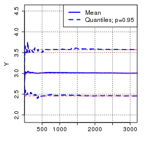

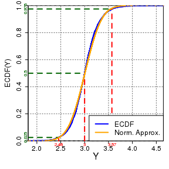

```r
cumPlot(S$Y,cex=0.5)
ECIPlot(S$Y,cex=0.5)
```

# 4 Presentation of results

To present the final results, the GUM advises to preserve 2 significant digits on the uncertainty and to round the mean value accordingly. Helper functions are proposed to print the results, also as coverage intervals.

```r
uncPrint(y=G$y.mu,uy=G$y.u)
```

```
#> Y = 3.00(22)
```

```r
CIPrint(y=G$y.mu,uy=G$y.u,fac=1.96,p=0.95)
```

```
#>
#> 95 percent C.I. = [2.56, 3.44]
```

# 5 Sensitivity Analysis

## 5.1 Analysis of variance

For independent input variables, the ANOVA column of the uncertainty budget produced by `gumCV()` provides all the required information for SA.

```r
G$anova
```

```
#> [1] 0.2 0.8
```

Let us call $S_i$ the relative contribution of variable $X_i$ to the variance of $Y$. Then, a variation of $p$ % of the variance of $X_i$ induces a variation of $S_i*p$ % of $Y$ variance. This result (exact for linear models) enables to assess the effect of each variable on $Y$ and to target the variables to improve in order to reach a desired variance for $Y$.

## 5.2 Inputs-output correlation

Samples from input variables and output can be used directly to calculate sensitivity indices. Scatterplots of the samples can be particularly informative, but do not provide numerical values.

The correlation coefficients $\mathrm{cor}(Y,X_{i})$ between $Y$ and the inputs $\mathbf{X}$ can be easily evaluated.

For a linear model, one has
$$\mathrm{cor}(Y,X_{i})=\sum_{j=1}^{k}\left(\frac{\partial Y}{\partial X_{j}}\right)_{\overline{x}}\frac{u(x_{j})}{u(y)}\mathrm{cor}(X_{i},X_{j})$$
For independent input variables, this simplifies to
$$\mathrm{cor}^{2}(Y,X_{i})=\frac{\left(\frac{\partial Y}{\partial X_{i}}\right)_{\overline{x}}^{2}u^{2}(x_{i})}{u^{2}(y)}\equiv ANOVA_{i}$$

Therefore, for linear models and independent variables, the correlation coefficients are directly related to the ANOVA.

This cannot be directly extended to nonlinear models, but using rank correlation coefficients (Spearman) instead of Person’s enable good results with monotonous functions.

One has also to remember that null correlation coefficients do not imply an absence of dependence between variables.

The function `SAPlot()` generates a matrix plot with both scatterplots and correlation coefficients.

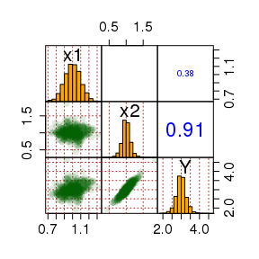

Inputs-output scatterplots and correlations.

```r
SAPlot(cbind(S$X,S$Y),cex=0.5)
```

The correlation coefficients can be obtained in base R:

```r
(CorP = cor(S$X,S$Y, method = "pearson"))
```

```
#>            Y
#> x1 0.3558354
#> x2 0.9347833
```

```r
cor(S$X,S$Y, method = "spearman")
```

```
#>            Y
#> x1 0.3800870
#> x2 0.9097654
```

## 5.3 Sobol indices

```
#>
#> Call:
#> sensitivity::soboljansen(model = fVector, X1 = X1, X2 = X2, nboot = nboot,     fExpr = fExpr)
#>
#> Model runs: 40000
#>
#> First order indices:
#>     original
#> x1 0.1277598
#> x2 0.8697099
#>
#> Total indices:
#>     original
#> x1 0.1302901
#> x2 0.8722402
```

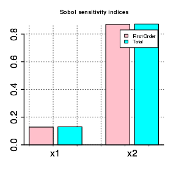

```r
z=with(params,
       sobolSA(fExpr=fExpr,x.mu=x.mu,x.u=x.u,x.pdf=x.pdf,x.df=x.df,
               graph=TRUE,cex=0.5)
       )
print(z)
```

## 5.4 Variance gradients

Variance gradients[^4] are calculated from the samples for independent $\mathbf{X}$ and $Y$. They require the additional evaluation of partial derivatives for each point of the sample.

$$G_{i}=\frac{E\left[\left(Y-\overline{y}\right)\frac{\partial Y}
{\partial X_{i}}\left(X_{i}-\overline{x}_{i}\right)\right]}
{u^{2}(y)}$$

```r
d= vgSA(fExpr=fExpr,x.mu=params$x.mu, x.u=params$x.u,
        X=S$X, Y=S$Y, silent=TRUE)
knitr::kable(d$budget)
```

|  | Valeur | Inc_Std. | VG |
| --- | --- | --- | --- |
| x1 | 1.000e+00 | 1.00e-01 | 1.26e-01 |
| x2 | 1.000e+00 | 1.00e-01 | 8.73e-01 |
| Y | 3.005e+00 | 2.75e-01 |  |

These indices are interpreted as follows: a variation of $p$ % of the variance of $X_i$ induces a variation of $G_i*p$ % of $Y$ variance. Except for linear models, where one recovers the ANOVA $G_{i}=ANOVA_{i}$, this interpretation is valid for small values of $p$. This is to be contrasted with other indices, such as Sobol’s, which quantify the effect on $Y$ of a cancellation of the input’s variance.

An originality of variance gradients indices is that , for non-linear models, they can be negative. In such cases, reducing the variance of a variable might induce an increase in the variance of $Y$.

## 5.5 Note

```r
signif(CorP^2,3)
```

```
#>        Y
#> x1 0.127
#> x2 0.874
```

# 6 Consolidated example: sum of squares

## 6.1 Model and variables definition

```r
# Expression analytique du modele
fExpr = expression( x1^2 + x2^2 )

# Variables incertaines
x1=0; x1.u=1.0; x1.pdf = "norm"
x2=1; x2.u=0.1; x2.pdf = "norm"
```

## 6.2 Résults

```r
# Collect parameters in environment
params=collectParams(fExpr)
```

### 6.2.1 GUM: Combinaison des variances

```r
G=with(params,
       gumCV(fExpr=fExpr,x.mu=x.mu,x.u=x.u,silent=TRUE)
       )
knitr::kable(G$budget)
```

|  | Valeur | Inc_Std. | J | J2.U2 | Contrib. |
| --- | --- | --- | --- | --- | --- |
| x1 | 0.000e+00 | 1.00e+00 | 0.00e+00 | 0.00e+00 | 0.00 |
| x2 | 1.000e+00 | 1.00e-01 | 2.00e+00 | 4.00e-02 | 1.00 |
| Y | 1.000e+00 | 2.00e-01 | <– | 4.00e-02 |  |

```r
uncPrint(y=G$y.mu,uy=G$y.u)
```

```
#> Y = 1.00(20)
```

```r
# Incertitude élargie
CIPrint(y=G$y.mu,uy=G$y.u,fac=1.96,p=0.95)
```

```
#>
#> 95 percent C.I. = [0.61, 1.39]
```

### 6.2.2 GUM-Supp1: Monte Carlo

```r
S=with(params,
       gumS2(fExpr=fExpr,x.mu=x.mu,x.u=x.u,x.pdf=x.pdf,x.df=x.df)
       )
```

```
#>
#> *** Monte Carlo Uncertainty Propagation:
#> 1st stage: 30 blocks
#> 2nd stage: 0 blocks
#>
#> Sample Size = 3.0e+03Y = 2.0(1.4)
#> 95 percent C.I. = [8,61]*10^-1
```

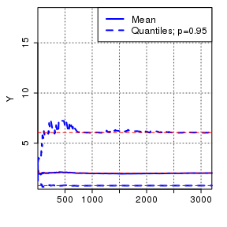

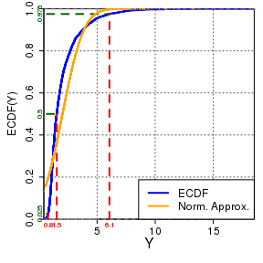

```r
cumPlot(S$Y,cex=0.5)
ECIPlot(S$Y,cex=0.5)
```

### 6.2.3 Analyse globale de sensibilité

#### 6.2.3.1 Corrélation entrées/sortie

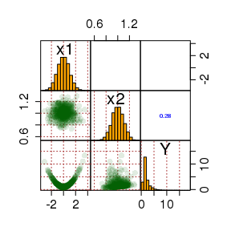

Inputs-output scatterplots and correlation.

```r
SAPlot(cbind(S$X,S$Y),cex=0.5)
```

#### 6.2.3.2 Indices de Sobol

```
#>
#> Call:
#> sensitivity::soboljansen(model = fVector, X1 = X1, X2 = X2, nboot = nboot,     fExpr = fExpr)
#>
#> Model runs: 40000
#>
#> First order indices:
#>      original
#> x1 0.97899989
#> x2 0.03742007
#>
#> Total indices:
#>      original
#> x1 0.96257993
#> x2 0.02100011
```

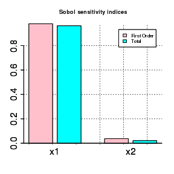

```r
z=with(params,
       sobolSA(fExpr=fExpr,x.mu=x.mu,x.u=x.u,x.pdf=x.pdf,x.df=x.df,
               graph=TRUE,cex=0.5)
       )
print(z)
```

#### 6.2.3.3 Gradients de la Variance

```r
d= vgSA(fExpr=fExpr,x.mu=params$x.mu, x.u=params$x.u, X=S$X, Y=S$Y, silent=TRUE)
knitr::kable(d$budget)
```

|  | Valeur | Inc_Std. | VG |
| --- | --- | --- | --- |
| x1 | 0.000e+00 | 1.00e+00 | 1.96e+00 |
| x2 | 1.000e+00 | 1.00e-01 | 1.72e-02 |
| Y | 2.021e+00 | 1.44e+00 |  |

[^1]: [GUM](http://www.bipm.org/utils/common/documents/jcgm/JCGM_100_2008_F.pdf)
[^2]: [GUM-Supp1](http://www.bipm.org/utils/common/documents/jcgm/JCGM_101_2008_E.pdf)
[^3]: Wübbeler et al. (2010) Metrologia 47:317
[^4]: Campanelli *et al.* (2013) *Meas. Sci. Tech.* **24**:025002